# FinalProject

**Fitting the model on the training data**

```python
lg.fit(x_train_S,y_train_S)
```

```
LogisticRegression()
```

**Checking the performance on the train dataset**

```
              precision    recall  f1-score   support

           0       0.91      0.94      0.92      3340
           1       0.71      0.61      0.65       832

    accuracy                           0.87      4172
   macro avg       0.81      0.77      0.79      4172
weighted avg       0.87      0.87      0.87      4172
```

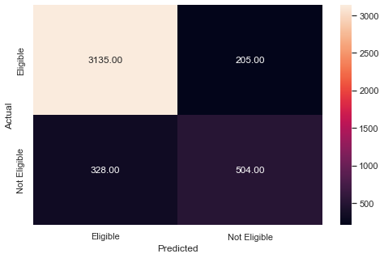

```python
y_pred_train_S = lg.predict(x_train_S)
metrics_score(y_train_S, y_pred_train_S)
```

**Checking the performance on the test dataset**

```
              precision    recall  f1-score   support

           0       0.90      0.95      0.93      1431
           1       0.74      0.59      0.66       357

    accuracy                           0.88      1788
   macro avg       0.82      0.77      0.79      1788
weighted avg       0.87      0.88      0.87      1788
```

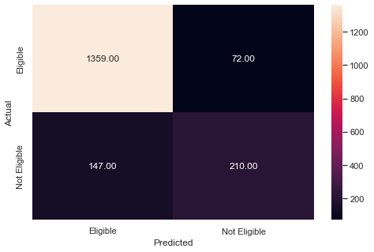

```python
y_pred_test_S = lg.predict(x_test_S)
metrics_score(y_test_S, y_pred_test_S)
```

**Note 31**: Performance of logistic regression (Feature Scaling)

- Train dataset:
  - Accuracy of 87%.
  - The recall is 94% for class 0 and 61% for class 1.
- Test dataset:
  - Accuracy of 88%.
  - The recall is 95% for class 0 and 59% for class 1.

5.4 Log Reg with Scaled Feature and Balanced Precision-Recall

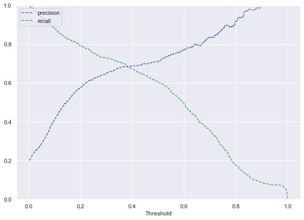

```python
# The Precision-Recall Curve for Logistic Regression


y_scores_lg_S = lg.predict_proba(x_train_S) # predict_proba gives the probability of each observation belonging to each class


precisions_lg, recalls_lg, thresholds_lg = precision_recall_curve(y_train_S, y_scores_lg_S[:, 1])

# Plot values of precisions, recalls, and thresholds
plt.figure(figsize = (10, 7))

plt.plot(thresholds_lg, precisions_lg[:-1], 'b--', label = 'precision')

plt.plot(thresholds_lg, recalls_lg[:-1], 'g--', label = 'recall')

plt.xlabel('Threshold')

plt.legend(loc = 'upper left')

plt.ylim([0, 1])

plt.show()
```

**Note 32**: The precision and the recall are balanced for a threshold of about 0.37.

```
              precision    recall  f1-score   support

           0       0.92      0.92      0.92      3340
           1       0.68      0.70      0.69       832

    accuracy                           0.88      4172
   macro avg       0.80      0.81      0.81      4172
weighted avg       0.88      0.88      0.88      4172
```

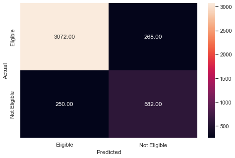

```python
optimal_threshold2 = .37

y_pred_proba_train_S = lg.predict_proba(x_train_S)

metrics_score(y_train_S, y_pred_proba_train_S[:, 1] > optimal_threshold2)
```

```
              precision    recall  f1-score   support

           0       0.92      0.93      0.93      1431
           1       0.71      0.68      0.69       357

    accuracy                           0.88      1788
   macro avg       0.81      0.81      0.81      1788
weighted avg       0.88      0.88      0.88      1788
```

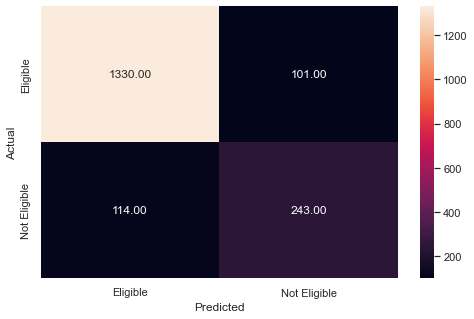

```python
optimal_threshold1 = .37

y_pred_proba_test_S = lg.predict_proba(x_test_S)

metrics_score(y_test_S, y_pred_proba_test_S[:, 1] > optimal_threshold1)
```

5.5 Overview of Log Reg Results

```python
Y_PRED = [y_pred_test, y_pred_proba_test[:, 1] > optimal_threshold1,
          y_pred_test_S, y_pred_proba_test_S[:, 1] > optimal_threshold2]

Y_TRUE = [y_test, y_test, y_test_S, y_test_S]

Res = np.empty((4,4),dtype=float)

for i in range(len(Y_PRED)):
    Res[i,:] = [classification_report(Y_TRUE[i], Y_PRED[i], output_dict=True)['macro avg']['f1-score'],
               classification_report(Y_TRUE[i], Y_PRED[i], output_dict=True)['macro avg']['recall'],
               classification_report(Y_TRUE[i], Y_PRED[i], output_dict=True)['macro avg']['precision'],
               classification_report(Y_TRUE[i], Y_PRED[i], output_dict=True)['accuracy']]
```

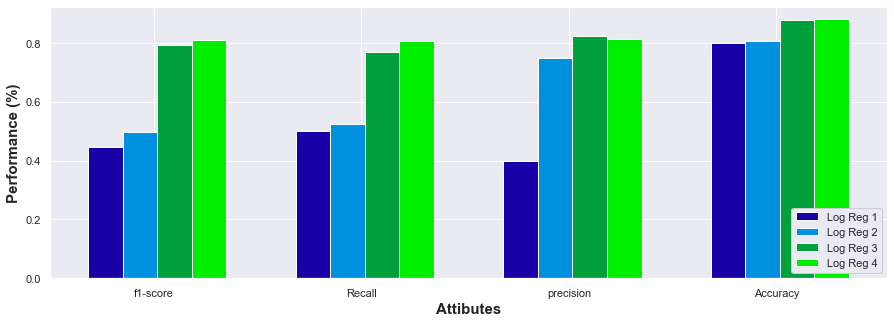

```python
barWidth = -0.1
data_p = Res.T
x = np.arange(data_p.shape[0])
dx = (np.arange(data_p.shape[1])-data_p.shape[1]/2.)/(data_p.shape[1]+2.)
d = 1./(data_p.shape[1]+2.)


fig, ax=plt.subplots(figsize =(15, 5))
for i in range(data_p.shape[1]):
    ax.bar(x+dx[i],data_p[:,i], width=d, label="label {}".format(i))

mdl = ['Log Reg 1', 'Log Reg 2', 'Log Reg 3', 'Log Reg 4']
plt.legend(mdl, framealpha=1, loc='lower right')
plt.xlabel('Attibutes', fontweight ='bold', fontsize = 15)
plt.ylabel('Performance (%)', fontweight ='bold', fontsize = 15)
plt.xticks([r + barWidth for r in range(len(Res[1]))],['f1-score', 'Recall', 'precision', 'Accuracy'])
plt.show()
```

```python
print('Log Reg 1: Logistic Regression')
print('Log Reg 2: Logistic Regression with Balanced Precision-Recall')
print('Log Reg 3: Logistic Regression with Scaled Feature')
print('Log Reg 4: Logistic Regression with Scaled Feature and Balanced Precision-Recall')
```

```
Log Reg 1: Logistic Regression
Log Reg 2: Logistic Regression with Balanced Precision-Recall
Log Reg 3: Logistic Regression with Scaled Feature
Log Reg 4: Logistic Regression with Scaled Feature and Balanced Precision-Recall
```

**Note 33**: Logistic Regression with balanced precision-recal and scaled feature had superior performance in Recal 1 (identifying customers defaulted on the loan) and good performances on accuracy and Recall 0 as well.

6. Decision Tree (DT) Model

6.1 DT with Default Hiperparameters

**Defining Decision tree model**

```python
dt = DecisionTreeClassifier(class_weight = {0: 0.2, 1: 0.8}, random_state = 1)
```

**Fitting decision tree model**

```python
dt.fit(x_train, y_train)
```

```
DecisionTreeClassifier(class_weight={0: 0.2, 1: 0.8}, random_state=1)
```

**Checking the performance on the train dataset**

```
              precision    recall  f1-score   support

           0       1.00      1.00      1.00      3340
           1       1.00      1.00      1.00       832

    accuracy                           1.00      4172
   macro avg       1.00      1.00      1.00      4172
weighted avg       1.00      1.00      1.00      4172
```

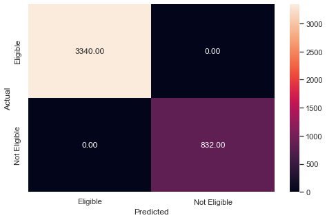

```python
y_train_pred_dt = dt.predict(x_train)

metrics_score(y_train, y_train_pred_dt)
```

**Checking performance on the test dataset**

```
              precision    recall  f1-score   support

           0       0.90      0.92      0.91      1431
           1       0.66      0.59      0.62       357

    accuracy                           0.86      1788
   macro avg       0.78      0.76      0.77      1788
weighted avg       0.85      0.86      0.85      1788
```

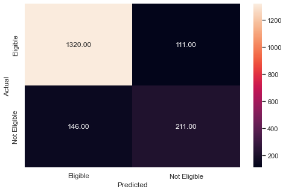

```python
y_test_pred_dt = dt.predict(x_test)

metrics_score(y_test, y_test_pred_dt)
```

**Checking feature importance**

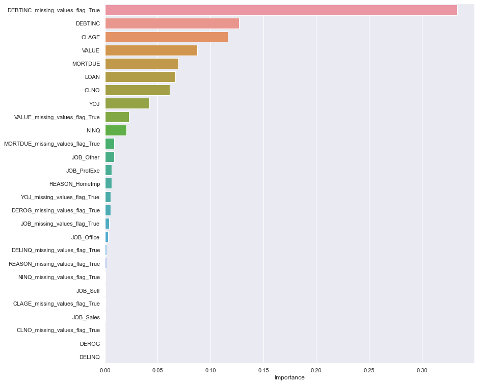

```python
importances = dt.feature_importances_

columns = X.columns

importance_df = pd.DataFrame(importances, index = columns, columns = ['Importance']).sort_values(by = 'Importance', ascending = False)

plt.figure(figsize = (13, 13))

sns.barplot(importance_df.Importance,importance_df.index);
```

**Note 34**: Performance of Decision Tree

- Train dataset:
  - Accuracy of 100%.
  - The recall is 100% for class 0 and 100% for class 1.
- Test dataset:
  - Accuracy of 86%.
  - The recall is 92% for class 0 and 59% for class 1.
- The Decision Tree is overfitting the training data.
- According to the Decision Tree, miss the DEBTINC information is the most important feature, followed by DEBTINC values, CLAGE, and VALUE.

6.2 DT with Tuned Hiperparameters

**Using GridSearch for Hyperparameter Tuning**

- Hyperparameter tuning is tricky in the sense that **there is no direct way to calculate how a change in the hyperparameter value will reduce the loss of your model**, so we usually resort to experimentation. We'll use Grid search to perform hyperparameter tuning.
- **Grid search is a tuning technique that attempts to compute the optimum values of hyperparameters.**
- **It is an exhaustive search** that is performed on the specific parameter values of a model.
- The parameters of the estimator/model used to apply these methods are **optimized by cross-validated grid-search** over a parameter grid.

**Criterion{“gini”, “entropy”}**

The function is to measure the quality of a split. Supported criteria are “gini” for the Gini impurity and “entropy” for the information gain.

**max_depth**

The maximum depth of the tree. If None, then nodes are expanded until all leaves are pure or until all leaves contain less than min_samples_split samples.

**min_samples_leaf**

The minimum number of samples is required to be at a leaf node. A split point at any depth will only be considered if it leaves at least min_samples_leaf training samples in each of the left and right branches. This may have the effect of smoothing the model, especially in regression.

```python
# Choose the type of classifier
dtree_estimator = DecisionTreeClassifier(class_weight = {0: 0.2, 1: 0.8}, random_state = 1)

# Grid of parameters to choose from
parameters = {'max_depth': np.arange(2, 7),
              'criterion': ['gini', 'entropy'],
              'min_samples_leaf': [5, 10, 20, 25]
             }

# Type of scoring used to compare parameter combinations
scorer = metrics.make_scorer(recall_score, pos_label = 1)

# Run the grid search
gridCV = GridSearchCV(dtree_estimator, parameters, scoring = scorer, cv = 10)

# Fitting the grid search on the train data
gridCV = gridCV.fit(x_train, y_train)

# Set the classifier to the best combination of parameters
dtree_estimator = gridCV.best_estimator_

# Fit the best estimator to the data
dtree_estimator.fit(x_train, y_train)
```

```
DecisionTreeClassifier(class_weight={0: 0.2, 1: 0.8}, max_depth=5,
                       min_samples_leaf=10, random_state=1)
```

#### Checking the performance on the train dataset

```
              precision    recall  f1-score   support

           0       0.95      0.88      0.91      3340
           1       0.62      0.80      0.70       832

    accuracy                           0.86      4172
   macro avg       0.78      0.84      0.80      4172
weighted avg       0.88      0.86      0.87      4172
```

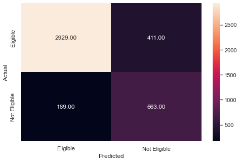

```python
y_train_tun_pred_dt = dtree_estimator.predict(x_train)

metrics_score(y_train, y_train_tun_pred_dt)
```

#### Checking the performance on the test dataset

```
              precision    recall  f1-score   support

           0       0.94      0.88      0.91      1431
           1       0.61      0.76      0.67       357

    accuracy                           0.85      1788
   macro avg       0.77      0.82      0.79      1788
weighted avg       0.87      0.85      0.86      1788
```

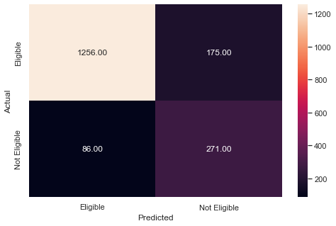

```python
y_test_tun_pred_dt = dtree_estimator.predict(x_test)

metrics_score(y_test, y_test_tun_pred_dt)
```

**Checking feature importance**

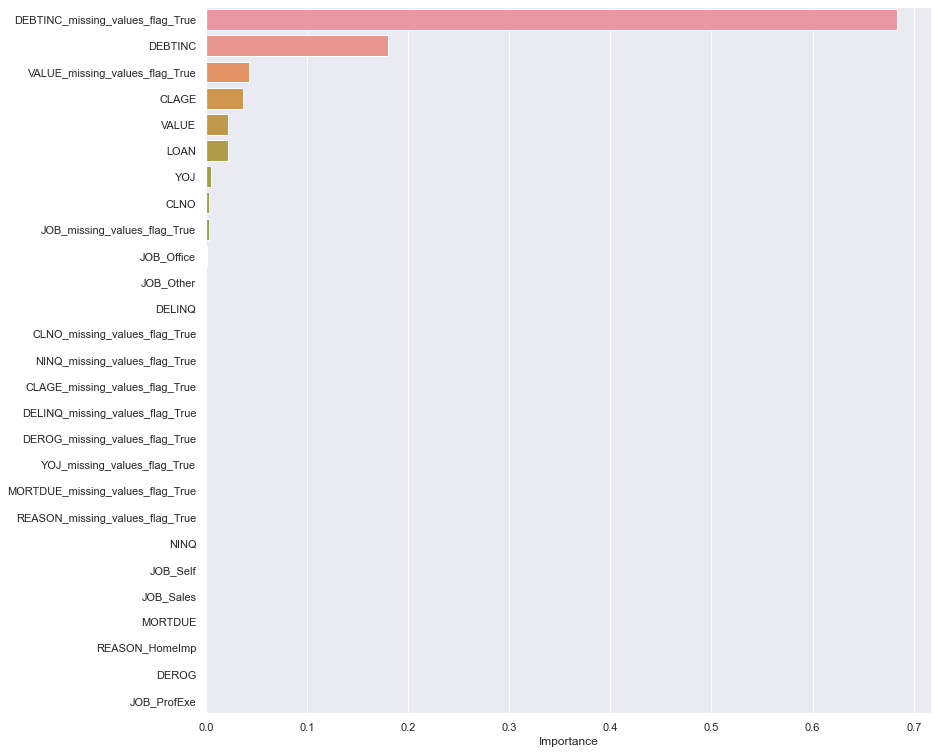

```python
importances = dtree_estimator.feature_importances_

columns = X.columns

importance_df = pd.DataFrame(importances, index = columns, columns = ['Importance']).sort_values(by = 'Importance', ascending = False)

plt.figure(figsize = (13, 13))

sns.barplot(importance_df.Importance, importance_df.index);
```

**Plotting the decision tree**

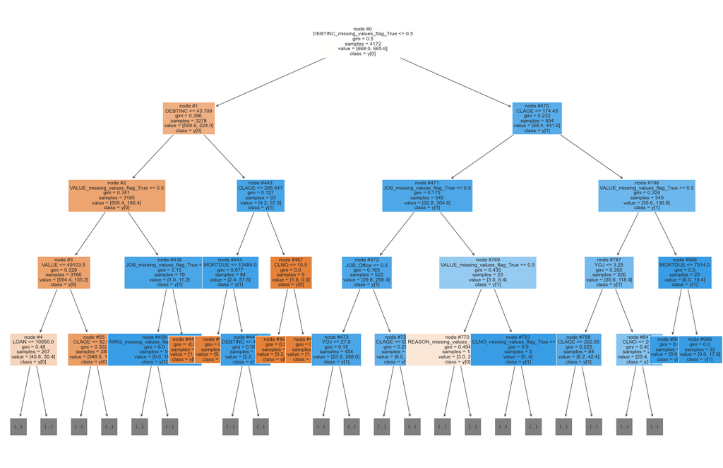

```python
features = list(X.columns)

plt.figure(figsize = (30, 20))

tree.plot_tree(dt, max_depth = 4, feature_names = features, filled = True, fontsize = 12, node_ids = True, class_names = True)

plt.show()
```

**Note 34**: Performance of DT with parameter tuning

- Train dataset:
  - Accuracy of 86\%.
  - The recall is 88\% for class 0 and 80\% for class 1.
- Test dataset:
  - Accuracy of 85\%.
  - The recall is 88\% for class 0 and 76\% for class 1.
- In comparison to the model with default values of hyperparameters, the performance on the training set has gone down significantly. This makes sense because we are trying to reduce overfitting.
- According to the tuned Decision Tree, miss the DEBTINC information is the most important feature, followed by DEBTINC values, miss the VALUE information, CLAGE, and VALUE.

6.3 Overview of DT Results

```python
Y_PRED = [y_test_pred_dt, y_test_tun_pred_dt]

Y_TRUE = [y_test, y_test]

Res = np.empty((2,4),dtype=float)

for i in range(len(Y_PRED)):
    Res[i,:] = [classification_report(Y_TRUE[i], Y_PRED[i], output_dict=True)['macro avg']['f1-score'],
               classification_report(Y_TRUE[i], Y_PRED[i], output_dict=True)['macro avg']['recall'],
               classification_report(Y_TRUE[i], Y_PRED[i], output_dict=True)['macro avg']['precision'],
               classification_report(Y_TRUE[i], Y_PRED[i], output_dict=True)['accuracy']]
```

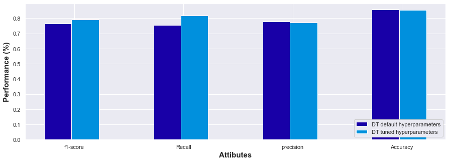

```python
data_p = Res.T
x = np.arange(data_p.shape[0])
dx = (np.arange(data_p.shape[1])-data_p.shape[1]/2.)/(data_p.shape[1]+2.)
d = 1./(data_p.shape[1]+2.)


fig, ax=plt.subplots(figsize =(15, 5))
for i in range(data_p.shape[1]):
    ax.bar(x+dx[i],data_p[:,i], width=d, label="label {}".format(i))

mdl = ['DT default hyperparameters', 'DT tuned hyperparameters']
plt.legend(mdl, framealpha=1, loc='lower right')
plt.xlabel('Attibutes', fontweight ='bold', fontsize = 15)
plt.ylabel('Performance (%)', fontweight ='bold', fontsize = 15)
plt.xticks([r + barWidth for r in range(len(Res[1]))],['f1-score', 'Recall', 'precision', 'Accuracy'])
plt.show()
```

**Note 34**: Decision Tree with tuned hyperparameters had superior performance on Recal, and good performances on accuracy, precision, and Recall 0 as well.

7. Random Forest (RF) Model

**Random Forest is a bagging algorithm where the base models are Decision Trees.** Samples are taken from the training data and on each sample a decision tree makes a prediction.

**The results from all the decision trees are combined together and the final prediction is made using voting or averaging.**

7.1 RF with Default Hiperparameters

**Defining Random forest CLassifier**

```python
rf_estimator = RandomForestClassifier(class_weight = {0: 0.2, 1: 0.8}, random_state = 1)
```

```python
rf_estimator.fit(x_train, y_train)
```

```
RandomForestClassifier(class_weight={0: 0.2, 1: 0.8}, random_state=1)
```

**Checking the performance on the train dataset**

```
              precision    recall  f1-score   support

           0       1.00      1.00      1.00      3340
           1       1.00      1.00      1.00       832

    accuracy                           1.00      4172
   macro avg       1.00      1.00      1.00      4172
weighted avg       1.00      1.00      1.00      4172
```

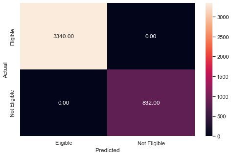

```python
y_pred_train_rf = rf_estimator.predict(x_train)

metrics_score(y_train, y_pred_train_rf)
```

**Checking performance on the test dataset**

```
              precision    recall  f1-score   support

           0       0.91      0.95      0.93      1431
           1       0.76      0.63      0.69       357

    accuracy                           0.89      1788
   macro avg       0.84      0.79      0.81      1788
weighted avg       0.88      0.89      0.88      1788
```

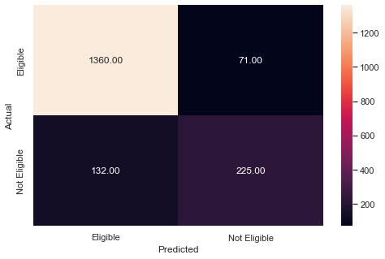

```python
y_pred_test_rf = rf_estimator.predict(x_test)

metrics_score(y_test, y_pred_test_rf)
```

**Feature importance of the Random Forest**

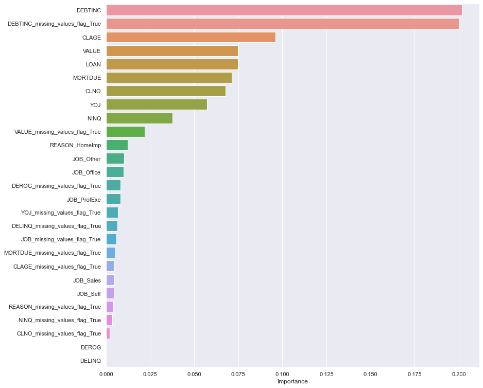

```python
importances = rf_estimator.feature_importances_

columns = X.columns

importance_df = pd.DataFrame(importances, index = columns, columns = ['Importance']).sort_values(by = 'Importance', ascending = False)

plt.figure(figsize = (13, 13))

sns.barplot(importance_df.Importance, importance_df.index);
```

**Note 35**: According to the Random Forest model, DEBTINC is the most important feature, followed by missing the DEBTINC values, CLAGE, and VALUE.

7.2 RF with Tuned Hiperparameters

- Hyperparameter tuning is tricky in the sense that **there is no direct way to calculate how a change in the hyperparameter value will reduce the loss of your model**, so we usually resort to experimentation. We'll use Grid search to perform hyperparameter tuning.
- **Grid search is a tuning technique that attempts to compute the optimum values of hyperparameters.**
- **It is an exhaustive search** that is performed on the specific parameter values of a model.
- The parameters of the estimator/model used to apply these methods are **optimized by cross-validated grid-search** over a parameter grid.

**n_estimators**: The number of trees in the forest.

**min_samples_split**: The minimum number of samples required to split an internal node:

**min_samples_leaf**: The minimum number of samples required to be at a leaf node.

**max_features{“auto”, “sqrt”, “log2”, 'None'}**: The number of features to consider when looking for the best split.

- If “auto”, then max_features=sqrt(n_features).
- If “sqrt”, then max_features=sqrt(n_features) (same as “auto”).
- If “log2”, then max_features=log2(n_features).
- If None, then max_features=n_features.

```python
# Choose the type of classifier
rf_estimator_tuned = RandomForestClassifier(class_weight = {0: 0.2, 1: 0.8}, random_state = 1)

# Grid of parameters to choose from
params_rf = {
        "n_estimators": [100, 250, 500],
        "min_samples_leaf": np.arange(1, 4, 1),
        "max_features": [0.7, 0.9, 'auto'],
}


# Type of scoring used to compare parameter combinations - recall score for class 1
scorer = metrics.make_scorer(recall_score, pos_label = 1)

# Run the grid search
grid_obj = GridSearchCV(rf_estimator_tuned, params_rf, scoring = scorer, cv = 5)

#fit the GridSearch on train dataset
grid_obj = grid_obj.fit(x_train, y_train)

# Set the classifier to the best combination of parameters
rf_estimator_tuned = grid_obj.best_estimator_

# Fit the best algorithm to the data
rf_estimator_tuned.fit(x_train, y_train)
```

```
RandomForestClassifier(class_weight={0: 0.2, 1: 0.8}, min_samples_leaf=3,
                       n_estimators=250, random_state=1)
```

#### Checking the performance on the train dataset

```
              precision    recall  f1-score   support

           0       0.99      0.94      0.97      3340
           1       0.80      0.97      0.88       832

    accuracy                           0.95      4172
   macro avg       0.90      0.96      0.92      4172
weighted avg       0.95      0.95      0.95      4172
```

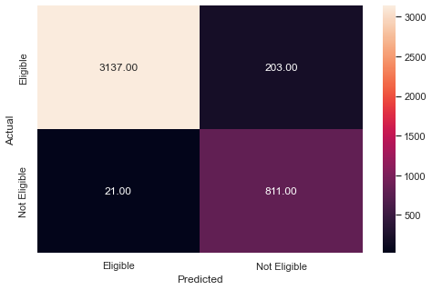

```python
y_pred_train_rf_tuned = rf_estimator_tuned.predict(x_train)

metrics_score(y_train, y_pred_train_rf_tuned)
```

#### Checking the performance on the test dataset

```
              precision    recall  f1-score   support

           0       0.94      0.91      0.92      1431
           1       0.69      0.75      0.71       357

    accuracy                           0.88      1788
   macro avg       0.81      0.83      0.82      1788
weighted avg       0.89      0.88      0.88      1788
```

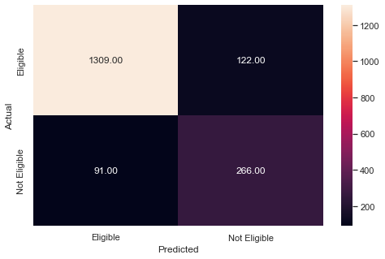

```python
y_pred_test_rf_tuned = rf_estimator_tuned.predict(x_test)

metrics_score(y_test, y_pred_test_rf_tuned)
```

**Feature importance of the tuned Random Forest**

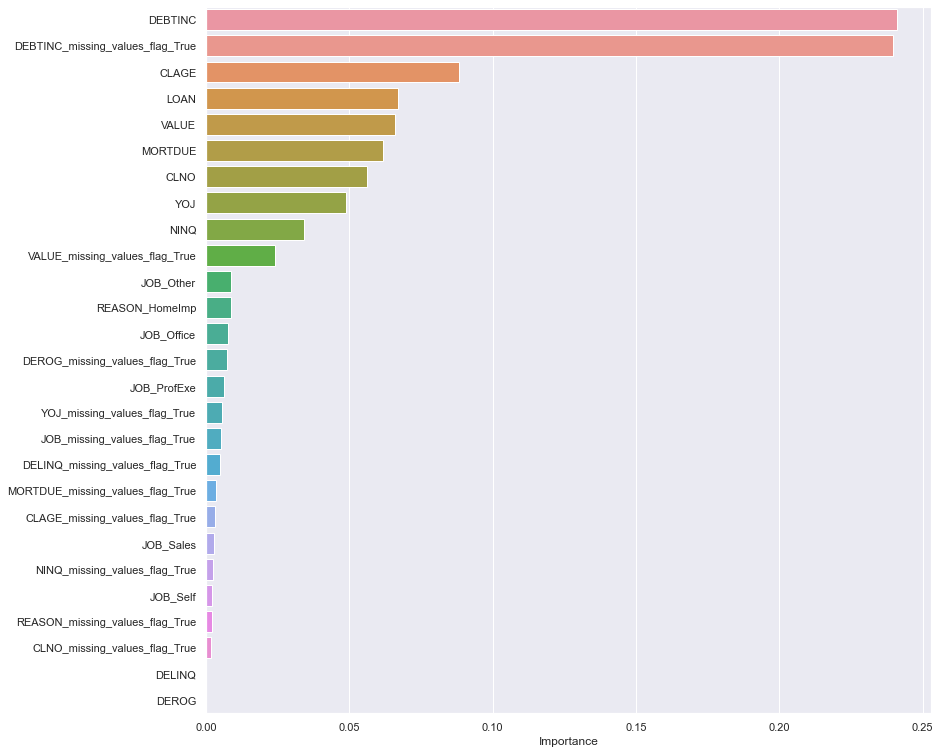

```python
importances = rf_estimator_tuned.feature_importances_

columns = X.columns

importance_df = pd.DataFrame(importances, index = columns, columns = ['Importance']).sort_values(by = 'Importance', ascending = False)

plt.figure(figsize = (13, 13))

sns.barplot(importance_df.Importance, importance_df.index);
```

**Note 36**: According to the tuned Random Forest model, DEBTINC is the most important feature, followed by missing the DEBTINC values, CLAGE, and LOAN.

7.3 Overview of RF Results

```python
Y_PRED = [y_pred_test_rf, y_pred_test_rf_tuned]

Y_TRUE = [y_test, y_test]

Res = np.empty((2,4),dtype=float)

for i in range(len(Y_PRED)):
    Res[i,:] = [classification_report(Y_TRUE[i], Y_PRED[i], output_dict=True)['macro avg']['f1-score'],
               classification_report(Y_TRUE[i], Y_PRED[i], output_dict=True)['macro avg']['recall'],
               classification_report(Y_TRUE[i], Y_PRED[i], output_dict=True)['macro avg']['precision'],
               classification_report(Y_TRUE[i], Y_PRED[i], output_dict=True)['accuracy']]
```

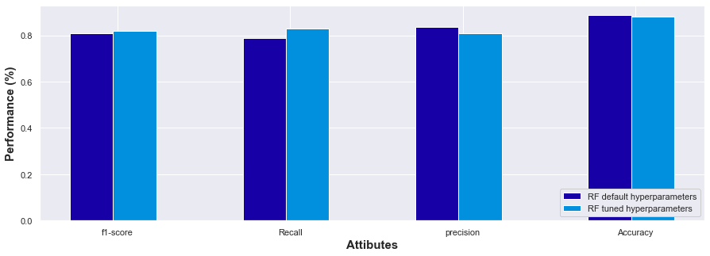

```python
data_p = Res.T
x = np.arange(data_p.shape[0])
dx = (np.arange(data_p.shape[1])-data_p.shape[1]/2.)/(data_p.shape[1]+2.)
d = 1./(data_p.shape[1]+2.)


fig, ax=plt.subplots(figsize =(15, 5))
for i in range(data_p.shape[1]):
    ax.bar(x+dx[i],data_p[:,i], width=d, label="label {}".format(i))

mdl = ['RF default hyperparameters', 'RF tuned hyperparameters']
plt.legend(mdl, framealpha=1, loc='lower right')
plt.xlabel('Attibutes', fontweight ='bold', fontsize = 15)
plt.ylabel('Performance (%)', fontweight ='bold', fontsize = 15)
plt.xticks([r + barWidth for r in range(len(Res[1]))],['f1-score', 'Recall', 'precision', 'Accuracy'])
plt.show()
```

**Note 37**: Random Forest with tuned hyperparameters has presented a superior performance regarding recall..

8. Comparing Model Performances

```python
models = ['Logistic Regression', 'Log Reg with Balanced Precision-Recall', 'Log Reg with Scaled Feature',
          'Log Reg with Scaled Feature and Balanced Precision-Recall', 'DT with Default Hiperparameters',
          'DT with Tuned Hiperparameters', 'RF Default Hiperparameters', 'RF with Tuned Hiperparameters']

Y_PRED = [y_pred_test, y_pred_proba_test[:, 1] > optimal_threshold1, y_pred_test_S, y_pred_proba_test_S[:, 1] > optimal_threshold2, y_test_pred_dt, y_test_tun_pred_dt,
         y_pred_test_rf, y_pred_test_rf_tuned]

Y_TRUE = [y_test, y_test, y_test_S, y_test_S, y_test, y_test, y_test, y_test]

Res = np.empty((8,4),dtype=float)

for i in range(len(Y_PRED)):
    Res[i,:] = [classification_report(Y_TRUE[i], Y_PRED[i], output_dict=True)['macro avg']['f1-score'],
               classification_report(Y_TRUE[i], Y_PRED[i], output_dict=True)['macro avg']['recall'],
               classification_report(Y_TRUE[i], Y_PRED[i], output_dict=True)['macro avg']['precision'],
               classification_report(Y_TRUE[i], Y_PRED[i], output_dict=True)['accuracy']]
Res = Res*100
```

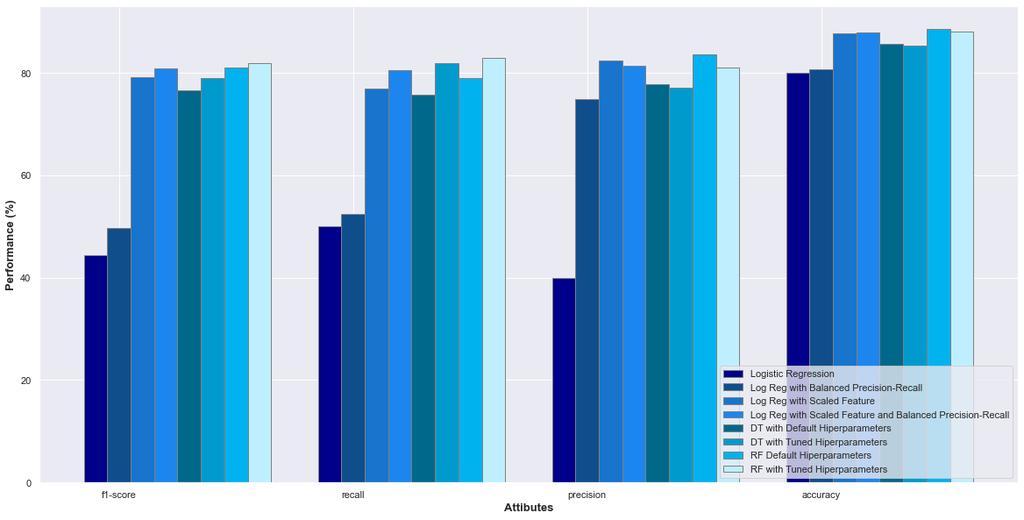

```python
barWidth = 0.1
fig = plt.subplots(figsize =(20, 10))

# Set position of bar on X axis
br1 = np.arange(len(Res[0]))
br2 = [x + barWidth for x in br1]
br3 = [x + barWidth for x in br2]
br4 = [x + barWidth for x in br3]
br5 = [x + barWidth for x in br4]
br6 = [x + barWidth for x in br5]
br7 = [x + barWidth for x in br6]
br8 = [x + barWidth for x in br7]

# Make the plot
plt.bar(br1, Res[0], color ='#00008B', width = barWidth, edgecolor ='grey', label = models[0])
plt.bar(br2, Res[1], color ='#104E8B', width = barWidth, edgecolor ='grey', label = models[1])
plt.bar(br3, Res[2], color ='#1874CD', width = barWidth, edgecolor ='grey', label = models[2])
plt.bar(br4, Res[3], color ='#1C86EE', width = barWidth, edgecolor ='grey', label = models[3])
plt.bar(br5, Res[4], color ='#00688B', width = barWidth, edgecolor ='grey', label = models[4])
plt.bar(br6, Res[5], color ='#009ACD', width = barWidth, edgecolor ='grey', label = models[5])
plt.bar(br7, Res[6], color ='#00B2EE', width = barWidth, edgecolor ='grey', label = models[6])
plt.bar(br8, Res[7], color ='#BFEFFF', width = barWidth, edgecolor ='grey', label = models[7])

# Adding Xticks
plt.xlabel('Attibutes', fontweight ='bold', fontsize = 13)
plt.ylabel('Performance (%)', fontweight ='bold', fontsize = 13)
plt.xticks([r + barWidth for r in range(len(Res[0]))],['f1-score', 'recall', 'precision', 'accuracy'])
plt.legend(loc='lower right')
plt.show()
```

**Note 38**:

- Summary of models results:
  - **F1-Score > 80\%**
    - Logistic Regression with Scaling Feature and Balanced Precision-Recall.
    - Random Forest with Default Hyperparameters.
    - Random Forest with Tuned Hyperparameters.
  - **Recall > 80\%**
    - Logistic Regression with Scaling Feature and Balanced Precision-Recall.
    - Decision Tree with Tuned Hyperparameters.
    - Random Forest with Tuned Hyperparameters.
  - **Precision > 80\%**
    - Logistic Regression with Scaling Feature.
    - Logistic Regression with Scaling Feature and Balanced Precision-Recall.
    - Random Forest with Default Hyperparameters.
    - Random Forest with Tuned Hyperparameters.
  - **Accuracy > 80\%**
    - All of them.
- **Models with all attributes > 80\%**
  - Logistic Regression with Scaling Feature and Balanced Precision-Recall.
  - Random Forest with Tuned Hyperparameters.
- **Model with higher Recall**
  - Random Forest with Tuned Hyperparameters (~83\%)

9. Conclusions and Busines Recomendations

9.1 Answering the Key Questions

- **Key question 1: What drives loan default?**
- **Answer**:
  - Customers with a high Debt-to income ratio tend to become defaulted on loans **(note 20)**.
    - 93% of customers with a Debt-to income ratio lower than 25 can afford the loan.
    - Roughly 50% of customers with a Debt-to income ratio higher than 43 have defaulted on the loan.
    - Customers with a Debt-to income ratio higher than 45 have always defaulted on the loan.
  - The reason why the loan is required does not interfere with default **(note 21)**.
- **Key question 2: What factors can be important to identify loan defaulters?**
- **Answer**:
- From the **Exploratory Data Analysis** Debt-to income ratio (`DEBTINC`) is the most important feature to be analyzed:
  - When the customers do have the `DEBTINC` info in the loan application:
    - Customers with a high Debt-to income ratio tend to become defaulted on loans **(note 20)**.
    - ~9\% of the clients with `DEBTINC` info have defaulted on the loan **(Note 25)**.
  - When the customers do not have the `DEBTINC` inifo in the loan application:
    - ~62\% of the clients missing `DEBTINC` info have defaulted on the loan **(Note 25)**.
- From the chosen model, **Random Forest with Tuned Hyperparameters**:
  - DEBTINC is the most important feature, followed by missing the DEBTINC values, CLAGE, and LOAN **(Note 36)**.
- Besides, when the customer miss the information regarding the **current value of property** (`VALUE`) they tend to become defaulted on loan:
  - ~94\% of the clients missing `VALUE` info defaulted in loan **(Note 26)**
- **Key question 3: How to model loan default as a function of other variables?**
- **Answer**:
- From the 13 input data, we can treat the binary variable indicating if a client has defaulted on a loan or not as the target and the remaining data as features.
- As the target is a binary variable, we can use the Logistic Regression model to classify a client given the 12 features.
  - In the Logistic Regression Model, we can analyze the impact of balancing precision-recall as well as scaling the features.
- We can use a Decision Tree and a Random Forest models to classify the clients based on the 12 features.
  - In these models, we can analyze the impact of tuning hyperparameters.
- We can choose the best model by analyzing the following attributes:
  - **Accuracy:** The fraction of classifications (eligible and not eligible clients) that the model has got correctly.
  - **Precision:** The fraction of **clients classified as not elegible** that are **actual not elegible clients**.
  - **Recall:** The fraction of **actual not eligible clients** that were **classified as not eligible clients**.
  - **F1-Score:** Weighted average of precision and recall
- As explained before, **RECALL** is the most important attribute (We want to avoid predicting an applicant is elegible when the applicant actually is not elegible), even though the other attributes have also to be taken into account in the final decision.
- The best model is the **Random Forest with Tuned Hyperparameters**.
- **Key question 4: How to use this model to automate the decisions of loan approval?**
- **Answer**:
- Now, with the **Random Forest with Tuned Hyperparameters** model, a set of features of a new application can be classified in Eligible (predicting BAD = 0) and Not Eligible (predicting BAD=1).
- **Key question 5: How to cut down on losses by loan defaults?**
- **Answer**:
- The bank should not approve loans to those customers with a debt-to-income ratio higher than 40, as those customers have very high chances of defaulting. For those customers, the bank should consider approving the loan only if the age of the oldest credit line is superior to 285 months.
- The bank should avoid approving loans in applications missing the debt-to-income ratio.

9.2 Busines Recommendations

- The bank should not approve loans to those customers with a debt-to-income ratio higher than 40, as those customers have very high chances of defaulting. For those customers, the bank should consider approving the loan only if the age of the oldest credit line is superior to 285 months.
- The bank should pre-approve loans to those customers with a debt-to-income ratio of less than 25, (use the proposed model for the final decision) as those customers have very high chances of repaying.
- The bank should avoid approving loans in applications missing the debt-to-income ratio.
- Missing value was identified as a characteristic of great importance in the decision-making of loan approval. In particular, missing values for the debt-to-income ratio and the current value of the property appeared as the main factors in several models tested.
- Thus, stakeholders should promote the importance of this information during the application for the loan to better identify customers with higher chances to default while improving the forecast model.

9.4 Risks and Challenges

- Although the proposed model has effectively identified eligible and ineligible consumers for the loan, the model does not guarantee 100% accuracy. Thus, the model should be used to assist in decision-making.
- Finally, the proposed model will be more effective when used in loan applications with the same features considered in this study.